# Visualizaciones Data

```python
import pandas as pd
import matplotlib.pyplot as plt
import numpy as np
import matplotlib.ticker as mtick
```

```python
data=pd.read_excel('data_final_2.xlsx',header=0)
```

```python
data.head()
```

|  | Unnamed: 0 | IDENTIFICADOR | COD_CIUDAD_LABOR | CIUDAD_RESIDENCIA | NRO_HIJOS | CIUDAD_LABOR | JORNADA_LABORAL_MES | FECHA_NACIMIENTO | EDAD | GENERACION | ... | CARGO_CORPORATIVO | CAUSAL_FIN_CONTRATO | ESTRATO | NIVEL_ESTUDIO | ESTADO_CIVIL | FECHA_ACT | INACTIVO | ACTIVO | ALTA | SECTOR |
| --- | --- | --- | --- | --- | --- | --- | --- | --- | --- | --- | --- | --- | --- | --- | --- | --- | --- | --- | --- | --- | --- |
| 0 | 0 | AA0578Z777 | 11001 | BOGOTA | 0 | BOGOTA | 240 | 1988-01-02 | 34.0 | MILLENIALS | ... | OPERATIVO | NONE | MEDIO | CARRERA TECNOLOGICA | COHABITANTE | 2022-04-28 23:10:01 | 0 | 1 | 0 | ACTIVIDADES DE SERVICIOS ADMINISTRATIVOS Y DE ... |
| 1 | 1 | A059985A6Z | 19573 | PUERTO TEJADA | 0 | PUERTO TEJADA | 240 | 1991-07-28 | 30.0 | MILLENIALS | ... | OPERATIVO | 04-FIN DE OBRA O LABOR | BAJO | NONE | SOLTERO/A | 2022-04-28 23:10:02 | 1 | 0 | 0 | INFORMACION Y COMUNICACIONES |
| 2 | 2 | A0Z6A30895 | 5045 | MEDELLIN | 0 | APARTADO | 240 | 1986-02-16 | 36.0 | MILLENIALS | ... | OPERATIVO | NONE | BAJO | CARRERA TECNICA | SOLTERO/A | 2022-04-28 23:10:04 | 0 | 1 | 0 | COMERCIO AL POR MAYOR Y AL POR MENOR; REPARACI... |
| 3 | 3 | A06A370A34 | 17877 | VITERBO | 0 | VITERBO | 240 | 1989-09-08 | 32.0 | MILLENIALS | ... | OPERATIVO | NONE | BAJO | CARRERA TECNICA | SOLTERO/A | 2022-04-28 23:10:04 | 0 | 1 | 0 | COMERCIO AL POR MAYOR Y AL POR MENOR; REPARACI... |
| 4 | 4 | A0AZ354544 | 11001 | BOGOTA | 0 | BOGOTA | 240 | 1989-07-24 | 32.0 | MILLENIALS | ... | OPERATIVO | NONE | BAJO | BACHILLERATO | SEPARADO/A | 2022-04-28 23:10:03 | 0 | 1 | 0 | INDUSTRIAS MANUFACTURERAS |

5 rows × 36 columns

We verify that there is only one register for each client

```python
print('Quantity of registers:', data.shape[0], '\n',
     'Employees:',len(set(data['IDENTIFICADOR'])), '\n',
     'Variables:', data.shape[1])
```

```
Quantity of registers: 122524
 Employees: 122524
 Variables: 36
```

# Category grouping

Next, a review of the presence of employees in the values and categories of the different variables will be made. If appropriate, a recategorization will be made for those categories with low presence.

## CIUDAD_RESIDENCIA

```python
z='CIUDAD_RESIDENCIA'

y=list(data[z].value_counts().index)
x=list(data[z].value_counts().values)
x_p=list(np.round(data[z].value_counts().values/sum(data[z].value_counts().values),4)*100)

d=pd.DataFrame({'City of residence':y, 'Employees':x, '%':x_p})

print(' Null registers:', data[data['CIUDAD_RESIDENCIA'].isnull()].shape[0], '\n',
'City "73408" Registers:', data[data['CIUDAD_RESIDENCIA']=='73408'].shape[0], '\n',
     'Cities:', len(set(data['CIUDAD_RESIDENCIA'])), '\n',
     'Percentage accumulated by the first 45 cities:', np.around(sum(d['%'].head(45)),2))
```

```
 Null registers: 0
 City "73408" Registers: 5
 Cities: 649
 Percentage accumulated by the first 45 cities: 89.99
```

There is a total of 649 different cities, of which 45 accumulate approximately 90\% of the records. Next, we graph the first 10 cities with the highest frequency where employees reside, with Bogotá being the city in which 28.15\% of all employees reside.

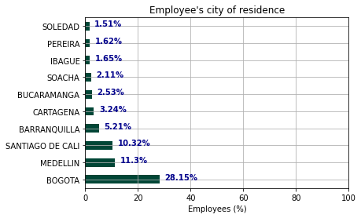

```python
d.head(10).plot(x='City of residence',y='%', kind='barh', colormap='PuBuGn_r', grid=True, legend=False)

for i in range(10):
    plt.text(d['%'][i]+2,i,str(round(d['%'][i],2))+'%',color='darkblue',size='medium',weight=1000)

plt.ylabel('')
plt.xlabel('Employees (%)')
plt.title("Employee's city of residence")
plt.xlim(0,100)

plt.show()
```

## NRO_HIJOS

For the variable NRO_HIJOS, we observe that the majority of employees do not have children, this group represents 85.87\% of the total number of employees, followed by those who only have one child, which represents 9.68\%. We must highlight that there is an employee with 8 children, this being the maximum number for this variable.

```python
z='NRO_HIJOS'

y=list(data[z].value_counts().index)
x=list(data[z].value_counts().values)
x_p=list(np.round(data[z].value_counts().values/sum(data[z].value_counts().values),4)*100)

d=pd.DataFrame({'Children':y, 'Employees':x, '%':x_p})

d
```

|  | Children | Employees | % |
| --- | --- | --- | --- |
| 0 | 0 | 105212 | 85.87 |
| 1 | 1 | 11865 | 9.68 |
| 2 | 2 | 4407 | 3.60 |
| 3 | 3 | 856 | 0.70 |
| 4 | 4 | 146 | 0.12 |
| 5 | 5 | 29 | 0.02 |
| 6 | 6 | 6 | 0.00 |
| 7 | 7 | 2 | 0.00 |
| 8 | 8 | 1 | 0.00 |

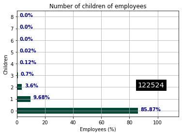

```python
z='NRO_HIJOS'

y=list(data[z].value_counts().index)
x=list(data[z].value_counts().values)
x_p=list(np.round(data[z].value_counts().values/sum(data[z].value_counts().values),4)*100)

d=pd.DataFrame({'Children':y, 'Employees':x, '%':x_p})

d.plot(x='Children',y='%', kind='barh', colormap='PuBuGn_r', grid=True, legend=False)

for i in range(d.shape[0]):
    plt.text(d['%'][i]+2,i,str(round(d['%'][i],2))+'%',color='darkblue',size='medium',weight=1000)
plt.text(max(d['%']),2,str(sum(d['Employees'])), fontsize='x-large', backgroundcolor='black',color='white')
plt.ylabel('Children')
plt.xlabel('Employees (%)')
plt.title('Number of children of employees')
plt.xlim(0,115)

plt.show()
```

## EDAD

Reviewing the age of the employees, we observe that most of them are between 20-30 years old and 30-40 years old, representing 52.2\% and 35.61\% of the employees, respectively.

```python
a = pd.cut(data['EDAD'], bins=np.arange(0,100,10), right=False)

z='Age interval'

y=list(a.value_counts().index)
x=list(a.value_counts().values)
x_p=list(np.round(a.value_counts().values/sum(a.value_counts().values),4)*100)

f=pd.DataFrame({'Age interval':y, 'Employees':x, '%':x_p})

f
```

|  | Age interval | Employees | % |
| --- | --- | --- | --- |
| 0 | [20, 30) | 63950 | 52.20 |
| 1 | [30, 40) | 43620 | 35.61 |
| 2 | [40, 50) | 11222 | 9.16 |
| 3 | [50, 60) | 1925 | 1.57 |
| 4 | [10, 20) | 1577 | 1.29 |
| 5 | [60, 70) | 192 | 0.16 |
| 6 | [70, 80) | 18 | 0.01 |
| 7 | [80, 90) | 1 | 0.00 |
| 8 | [0, 10) | 0 | 0.00 |

Based on the company's experience, ages older than 60 are grouped together and ages younger than 20 years are grouped into another new category, to which a single value was assigned, these are ages 61 and 19, respectively, which represent these categories.

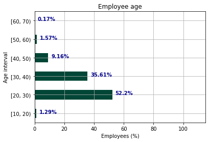

```python
data['EDAD_2'] = np.nan

for i in range(data.shape[0]):
    if data['EDAD'][i] <20:
        data['EDAD_2'][i]=str(19)
    elif data['EDAD'][i] >60:
        data['EDAD_2'][i]=str(61)
    elif data['EDAD'].isnull()[i]==True:
        data['EDAD_2'][i]='NO REGISTRA'
    else:
        data['EDAD_2'][i]=str(data['EDAD'][i])

g=data[data['EDAD_2']!='NO REGISTRA']['EDAD_2'].to_list()
f=pd.cut(g, bins=np.arange(10,80,10), right=False)

y=list(f.value_counts().index)
x=list(f.value_counts().values)
x_p=list(np.round(f.value_counts().values/sum(f.value_counts().values),4)*100)

d=pd.DataFrame({'Age interval':y, 'Employees':x, '%':x_p})

d.plot(x='Age interval',y='%', kind='barh', colormap='PuBuGn_r', grid=True, legend=False)

for i in range(d.shape[0]):
    plt.text(d['%'][i]+2,i,str(round(d['%'][i],2))+'%',color='darkblue',size='medium',weight=1000)
plt.ylabel('Age interval')
plt.xlabel('Employees (%)')
plt.title('Employee age')
plt.xlim(0,115)

plt.show()
```

## GENERACION

According to the date of birth of the employees, they were classified into four different categories, these are shown below. Generation Z and Millennials represent 91.41\% of the total number of employees, which is equivalent to the age distribution presented in previous steps.

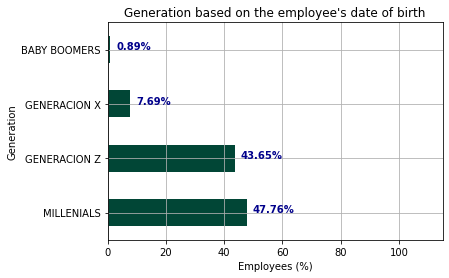

```python
z='GENERACION'

y=list(data[z].value_counts().index)
x=list(data[z].value_counts().values)
x_p=list(np.round(data[z].value_counts().values/sum(data[z].value_counts().values),4)*100)

d=pd.DataFrame({'Generation':y, 'Employees':x, '%':x_p})

d.plot(x='Generation',y='%', kind='barh', colormap='PuBuGn_r', grid=True, legend=False)

for i in range(d.shape[0]):
    plt.text(d['%'][i]+2,i,str(round(d['%'][i],2))+'%',color='darkblue',size='medium',weight=1000)
plt.ylabel('Generation')
plt.xlabel('Employees (%)')
plt.title("Generation based on the employee's date of birth")
plt.xlim(0,115)

plt.show()
```

## GENERO

In relation to gender, we see that there is a greater presence of women than men, representing 52.86\% of all employees.

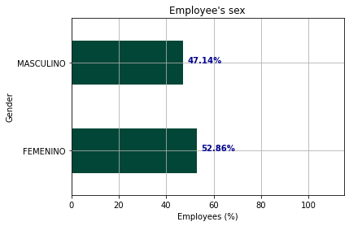

```python
z='GENERO'

y=list(data[z].value_counts().index)
x=list(data[z].value_counts().values)
x_p=list(np.round(data[z].value_counts().values/sum(data[z].value_counts().values),4)*100)

d=pd.DataFrame({'Gender':y, 'Employees':x, '%':x_p})

d.plot(x='Gender',y='%', kind='barh', colormap='PuBuGn_r', grid=True, legend=False)

for i in range(d.shape[0]):
    plt.text(d['%'][i]+2,i,str(round(d['%'][i],2))+'%',color='darkblue',size='medium',weight=1000)
plt.ylabel('Gender')
plt.xlabel('Employees (%)')
plt.title("Employee's sex")
plt.xlim(0,115)

plt.show()
```

## REGIONAL

There are seven regions with business operations for the company, of which the Central and Antioquia regions account for approximately 60\% of the presence of their employees.

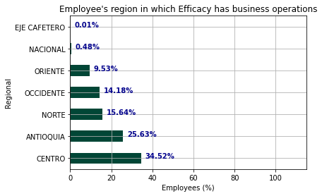

```python
z='REGIONAL'

y=list(data[z].value_counts().index)
x=list(data[z].value_counts().values)
x_p=list(np.round(data[z].value_counts().values/sum(data[z].value_counts().values),4)*100)

d=pd.DataFrame({'Regional':y, 'Employees':x, '%':x_p})

d.plot(x='Regional',y='%', kind='barh', colormap='PuBuGn_r', grid=True, legend=False)

for i in range(d.shape[0]):
    plt.text(d['%'][i]+2,i,str(round(d['%'][i],2))+'%',color='darkblue',size='medium',weight=1000)
plt.ylabel('Regional')
plt.xlabel('Employees (%)')
plt.title("Employee's region in which Efficacy has business operations")
plt.xlim(0,115)

plt.show()
```

## TIPO_CONTRATO

The type of contract that the employee has with the company is mostly POR OBRA O LABOR CONTRATADA, which represents 92.79\% of the contracts.

```python
z='TIPO_CONTRATO'

y=list(data[z].value_counts().index)
x=list(data[z].value_counts().values)
x_p=list(np.round(data[z].value_counts().values/sum(data[z].value_counts().values),4)*100)

d=pd.DataFrame({'Contract':y, 'Employees':x, '%':x_p})

d.head(10)
```

|  | Contract | Employees | % |
| --- | --- | --- | --- |
| 0 | POR OBRA O LABOR CONTRATADA | 113695 | 92.79 |
| 1 | INDEFINIDO | 2405 | 1.96 |
| 2 | TERMINO FIJO INFERIOR A UN ANO | 2373 | 1.94 |
| 3 | SENA ETAPA PRODUCTIVA | 1843 | 1.50 |
| 4 | SENA ETAPA ELECTIVA | 916 | 0.75 |
| 5 | TERMINO FIJO DE UN ANO | 817 | 0.67 |
| 6 | TERMINO FIJO ENTRE UNO Y TRES ANOS | 284 | 0.23 |
| 7 | ESTUDIANTE EN PRACTICA | 191 | 0.16 |

Given the low presence of most of the categories, they are grouped, finally leaving the variable with three categories as shown below:

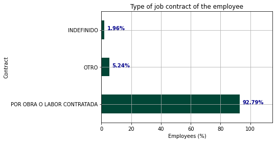

```python
contratos=['POR OBRA O LABOR CONTRATADA','INDEFINIDO']
data['TIPO_CONTRATO_2'] = np.nan

for i in range(data.shape[0]):
    if data['TIPO_CONTRATO'][i] in contratos:
        data['TIPO_CONTRATO_2'][i]=data['TIPO_CONTRATO'][i]
    else:
        data['TIPO_CONTRATO_2'][i]='OTRO'

z='TIPO_CONTRATO_2'

y=list(data[z].value_counts().index)
x=list(data[z].value_counts().values)
x_p=list(np.round(data[z].value_counts().values/sum(data[z].value_counts().values),4)*100)

d=pd.DataFrame({'Contract':y, 'Employees':x, '%':x_p})

d.plot(x='Contract',y='%', kind='barh', colormap='PuBuGn_r', grid=True, legend=False)

for i in range(d.shape[0]):
    plt.text(d['%'][i]+2,i,str(round(d['%'][i],2))+'%',color='darkblue',size='medium',weight=1000)
plt.ylabel('Contract')
plt.xlabel('Employees (%)')
plt.title('Type of job contract of the employee')
plt.xlim(0,115)

plt.show()
```

## FONDEX

```python
z='FONDEX'

y=list(data[z].value_counts().index)
x=list(data[z].value_counts().values)
x_p=list(np.round(data[z].value_counts().values/sum(data[z].value_counts().values),4)*100)

d=pd.DataFrame({'Contract':y, 'Employees':x, '%':x_p})

d.head(10)
```

|  | Contract | Employees | % |
| --- | --- | --- | --- |
| 0 | N | 115209 | 94.03 |
| 1 | S | 7225 | 5.90 |
| 2 | -1 | 90 | 0.07 |

Next, we proceed to change the label of the category "-1" to "No registra".

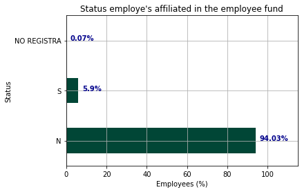

```python
fondo=['N','S']
data['FONDEX_2'] = np.nan

for i in range(data.shape[0]):
    if data['FONDEX'][i] in fondo:
        data['FONDEX_2'][i]=data['FONDEX'][i]
    else:
        data['FONDEX_2'][i]='NO REGISTRA'

z='FONDEX_2'

y=list(data[z].value_counts().index)
x=list(data[z].value_counts().values)
x_p=list(np.round(data[z].value_counts().values/sum(data[z].value_counts().values),4)*100)

d=pd.DataFrame({'Fondex':y, 'Employees':x, '%':x_p})

d.plot(x='Fondex',y='%', kind='barh', colormap='PuBuGn_r', grid=True, legend=False)

for i in range(d.shape[0]):
    plt.text(d['%'][i]+2,i,str(round(d['%'][i],2))+'%',color='darkblue',size='medium',weight=1000)
plt.ylabel('Status')
plt.xlabel('Employees (%)')
plt.title("Status employe's affiliated in the employee fund")
plt.xlim(0,115)

plt.show()
```

## NEGOCIO

The company has 6 business units, of which "Talento & Soluciones" and "Go to market" account for 86.81\% of the total number of employees, giving strong indications of the company's business interests.

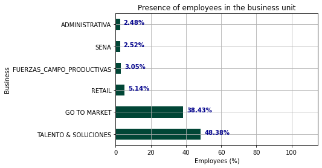

```python
z='NEGOCIO'

y=list(data[z].value_counts().index)
x=list(data[z].value_counts().values)
x_p=list(np.round(data[z].value_counts().values/sum(data[z].value_counts().values),4)*100)

d=pd.DataFrame({'Business':y, 'Employees':x, '%':x_p})

d.plot(x='Business',y='%', kind='barh', colormap='PuBuGn_r', grid=True, legend=False)

for i in range(d.shape[0]):
    plt.text(d['%'][i]+2,i,str(round(d['%'][i],2))+'%',color='darkblue',size='medium',weight=1000)
plt.ylabel('Business')
plt.xlabel('Employees (%)')
plt.title('Presence of employees in the business unit')
plt.xlim(0,115)

plt.show()
```

## FECHA_INGRESO

Given the presented count of employees who have joined the company year after year, a growth trend is perceived as time progresses. So far, 2021 has been the period with the highest employee income. Of the total number of employees in the study, 28.48\% joined in 2021.

```python
z=pd.to_datetime(data['FECHA_INGRESO']).dt.year

y=list(z.value_counts().index)
x=list(z.value_counts().values)
x_p=list(np.round(z.value_counts().values/sum(z.value_counts().values),4)*100)

d=pd.DataFrame({'Admission date':y, 'Employees':x, '%':x_p})

d.head(10)
```

|  | Admission date | Employees | % |
| --- | --- | --- | --- |
| 0 | 2021 | 34892 | 28.48 |
| 1 | 2019 | 32032 | 26.14 |
| 2 | 2020 | 21730 | 17.74 |
| 3 | 2022 | 15690 | 12.81 |
| 4 | 2018 | 13762 | 11.23 |
| 5 | 2017 | 1704 | 1.39 |
| 6 | 2016 | 1017 | 0.83 |
| 7 | 2015 | 510 | 0.42 |
| 8 | 2014 | 469 | 0.38 |
| 9 | 2013 | 192 | 0.16 |

Given the low presence of employees who started in 2017 and before, these time periods are left in only one, represented by the value '2017' as shown below:

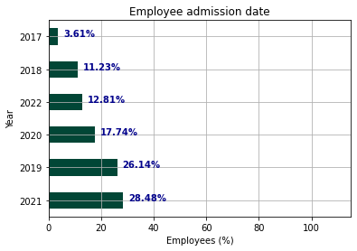

```python
ingreso=[2022,2021,2020,2019,2018]
data['FECHA_INGRESO_2'] = np.nan
año=pd.to_datetime(data['FECHA_INGRESO']).dt.year.to_list()

for i in range(data.shape[0]):
    if año[i] in ingreso:
        data['FECHA_INGRESO_2'][i]=str(año[i])
    else:
        data['FECHA_INGRESO_2'][i]=str(2017)

z=data['FECHA_INGRESO_2']

y=list(z.value_counts().index)
x=list(z.value_counts().values)
x_p=list(np.round(z.value_counts().values/sum(z.value_counts().values),4)*100)


d=pd.DataFrame({'Admission date':y, 'Employees':x, '%':x_p})

d.plot(x='Admission date',y='%', kind='barh', colormap='PuBuGn_r', grid=True, legend=False)
for i in range(d.shape[0]):
    plt.text(d['%'][i]+2,i,str(round(d['%'][i],2))+'%',color='darkblue',size='medium',weight=1000)
plt.ylabel('Year')
plt.xlabel('Employees (%)')
plt.title('Employee admission date')
plt.xlim(0,115)

plt.show()
```

For a more detailed visualization, the employee income series over time is shown, highlighting that as of 2018, the hiring of personnel increased significantly.

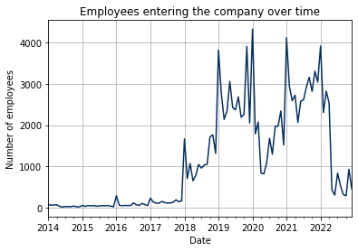

```python
months_by_year = pd.to_datetime(data['FECHA_INGRESO']).dt.to_period('M')
monthly_entry = data.groupby(months_by_year).size()

monthly_entry.plot(xlabel='Date', ylabel='Number of employees', title='Employees entering the company over time', grid=True, colormap='RdBu_r', xlim=('2014-01','2022-12'))
plt.show()
```

## FECHA_RETIRO

Observing the count of the retirement date per year, it can be seen that about 77.2\% of the employees in the database have retired, while 22.72\% are still active in the company.

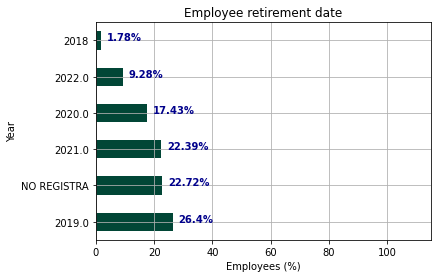

```python
z=pd.to_datetime(data['FECHA_RETIRO']).dt.year

y=list(z.value_counts().index)
x=list(z.value_counts().values)
x_p=list(np.round(z.value_counts().values/data.shape[0],4)*100)

d=pd.DataFrame({'Retirement date':y, 'Employees':x, '%':x_p})

retiro=[2022,2021,2020,2019]
retiro_2=[2018,2017,2016,2015,2012]

data['FECHA_RETIRO_2'] = np.nan
año=pd.to_datetime(data['FECHA_RETIRO']).dt.year.to_list()

for i in range(data.shape[0]):
    if año[i] in retiro:
        data['FECHA_RETIRO_2'][i]=str(año[i])
    elif año[i] in retiro_2:
        data['FECHA_RETIRO_2'][i]=str(2018)
    else:
        data['FECHA_RETIRO_2'][i]='NO REGISTRA'

z=data['FECHA_RETIRO_2']

y=list(z.value_counts().index)
x=list(z.value_counts().values)
x_p=list(np.round(z.value_counts().values/122524,4)*100)

d=pd.DataFrame({'Retirement date':y, 'Employees':x, '%':x_p})

d.plot(x='Retirement date',y='%', kind='barh', colormap='PuBuGn_r', grid=True, legend=False)
for i in range(d.shape[0]):
    plt.text(d['%'][i]+2,i,str(round(d['%'][i],2))+'%',color='darkblue',size='medium',weight=1000)
plt.ylabel('Year')
plt.xlabel('Employees (%)')
plt.title('Employee retirement date')
plt.xlim(0,115)

plt.show()
```

For a more detailed visualization, the count of retired employees over time in the company is shown, observing that at the end of each year the highest number of retired employees for their respective year is presented. Additionally, at the end of 2019, the largest number of retired employees was presented in the entire time window.

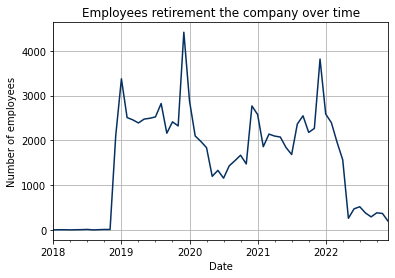

```python
months_by_year = pd.to_datetime(data['FECHA_RETIRO']).dt.to_period('M')
monthly_retirement = data.groupby(months_by_year).size()

monthly_retirement.plot(xlabel='Date', ylabel='Number of employees', title='Employees retirement the company over time', grid=True, colormap='RdBu_r', xlim=('2018-01','2022-12'))
plt.show()
```

## NIVEL_RIESGO

There are 5 risk levels, of which the "Nivel 2 Riesgo 1.044\%" risk covers 65.63\% of the risks to which employees are exposed. The risk of least presence is "Nivel 5 Riesgo 6.96\%" representing a little less than 1\%.

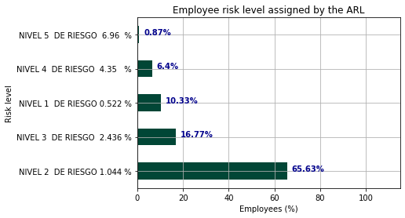

```python
z='NIVEL_RIESGO'

y=list(data[z].value_counts().index)
x=list(data[z].value_counts().values)
x_p=list(np.round(data[z].value_counts().values/sum(data[z].value_counts().values),4)*100)

d=pd.DataFrame({'Risk level':y, 'Employees':x, '%':x_p})

d.plot(x='Risk level',y='%', kind='barh', colormap='PuBuGn_r', grid=True, legend=False)

for i in range(d.shape[0]):
    plt.text(d['%'][i]+2,i,str(round(d['%'][i],2))+'%',color='darkblue',size='medium',weight=1000)
plt.ylabel('Risk level')
plt.xlabel('Employees (%)')
plt.title('Employee risk level assigned by the ARL')
plt.xlim(0,115)

plt.show()
```

## LINEA_SERVICIO

```python
z='LINEA_SERVICIO'

y=list(data[z].value_counts().index)
x=list(data[z].value_counts().values)
x_p=list(np.round(data[z].value_counts().values/sum(data[z].value_counts().values),4)*100)

d=pd.DataFrame({'Service line':y, 'Employees':x, '%':x_p})

d
```

|  | Service line | Employees | % |
| --- | --- | --- | --- |
| 0 | SUMINISTRO DE PERSONAL | 58120 | 47.44 |
| 1 | MERCADEO PROMOCION Y VENTAS | 21901 | 17.87 |
| 2 | ATENCION Y SERVICIO | 19913 | 16.25 |
| 3 | MERCADEO MERCHANDISING | 11818 | 9.65 |
| 4 | GESTION DE PROCESOS ADMINISTRATIVOS | 6709 | 5.48 |
| 5 | MERCADEO DIRECTO OPERADOR PERSONAL | 1479 | 1.21 |
| 6 | GESTION PROCESOS COMPLEMEN. A LA PROD. B | 879 | 0.72 |
| 7 | PRODUCCION Y LOGISTICA | 791 | 0.65 |
| 8 | LICE-CAMPANAS Y EVENTOS | 633 | 0.52 |
| 9 | MERCHANDISING EXPRESS | 231 | 0.19 |
| 10 | GESTIONDE PROCESOS ADMINISTRATIVO | 50 | 0.04 |

Given the above, we proceed to group the categories with low presence, finally ending with six categories as shown below

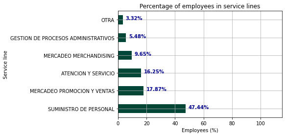

```python
data['LINEA_SERVICIO_2']=np.nan
linea=['SUMINISTRO DE PERSONAL','MERCADEO PROMOCION Y VENTAS','ATENCION Y SERVICIO','MERCADEO MERCHANDISING','GESTION DE PROCESOS ADMINISTRATIVOS']

for i in range(data.shape[0]):
    if data['LINEA_SERVICIO'][i] in linea:
        data['LINEA_SERVICIO_2'][i] = data['LINEA_SERVICIO'][i]
    else:
        data['LINEA_SERVICIO_2'][i]='OTRA'

z='LINEA_SERVICIO_2'

y=list(data[z].value_counts().index)
x=list(data[z].value_counts().values)
x_p=list(np.round(data[z].value_counts().values/sum(data[z].value_counts().values),4)*100)

d=pd.DataFrame({'Service line':y, 'Employees':x, '%':x_p})

d.plot(x='Service line',y='%', kind='barh', colormap='PuBuGn_r', grid=True, legend=False)

for i in range(d.shape[0]):
    plt.text(d['%'][i]+2,i,str(round(d['%'][i],2))+'%',color='darkblue',size='medium',weight=1000)
plt.ylabel('Service line')
plt.xlabel('Employees (%)')
plt.title('Percentage of employees in service lines')
plt.xlim(0,115)

plt.show()
```

## EPS

Within the data there are 62 different HCF (EPS in Spanish), being "SALUD TOTAL S.A." and "SURA EPS", the HCFs with the greatest presence among employees, representing 34.79\% of total registrations.

```python
z='EPS'

y=list(data[z].value_counts().index)
x=list(data[z].value_counts().values)
x_p=list(np.round(data[z].value_counts().values/sum(data[z].value_counts().values),4)*100)

d=pd.DataFrame({'HCF':y, 'Employees':x, '%':x_p})

d
```

|  | HCF | Employees | % |
| --- | --- | --- | --- |
| 0 | SALUD TOTAL S.A. | 22055 | 18.00 |
| 1 | SURA EPS | 20566 | 16.79 |
| 2 | SANITAS S.A. | 14645 | 11.95 |
| 3 | FAMISANAR LTDA CAFAM- COLSUBSIDIO | 13617 | 11.11 |
| 4 | NUEVA EPS | 12549 | 10.24 |
| ... | ... | ... | ... |
| 57 | NO USAR NO EXISTE | 1 | 0.00 |
| 58 | FONDO DE PRESTACIONES SOCIALES DEL MAGIS | 1 | 0.00 |
| 59 | COMFENALCO ANTIOQUIA | 1 | 0.00 |
| 60 | UNISALUD | 1 | 0.00 |
| 61 | UNIVERSIDAD DE ANTIOQUIA DIVISION SALUD7 | 1 | 0.00 |

62 rows × 3 columns

Given the low presence of some HCFs, we proceed to group them in such a way that they represent approximately 10\% of the total records, finally ending with 14 HCFs as shown below:

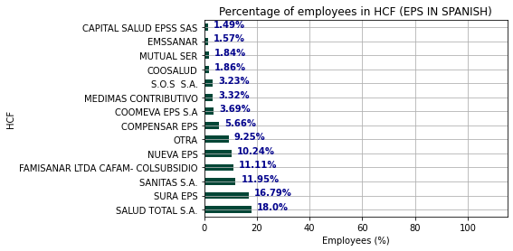

```python
eps=d['HCF'][0:13].to_list()
data['EPS_2']=np.nan

for i in range(data.shape[0]):
    if data['EPS'][i] in eps:
        data['EPS_2'][i] = data['EPS'][i]
    else:
        data['EPS_2'][i] = 'OTRA'

z='EPS_2'

y=list(data[z].value_counts().index)
x=list(data[z].value_counts().values)
x_p=list(np.round(data[z].value_counts().values/sum(data[z].value_counts().values),4)*100)

d=pd.DataFrame({'HCF':y, 'Employees':x, '%':x_p})

d.plot(x='HCF',y='%', kind='barh', colormap='PuBuGn_r', grid=True, legend=False)

for i in range(d.shape[0]):
    plt.text(d['%'][i]+2,i,str(round(d['%'][i],2))+'%',color='darkblue',size='medium',weight=1000)
plt.ylabel('HCF')
plt.xlabel('Employees (%)')
plt.title('Percentage of employees in HCF (EPS IN SPANISH)')
plt.xlim(0,115)

plt.show()
```

## CARGO_CORPORATIVO

There are 4 corporate positions, of which "OPERATIVO" represents 82.39\% as shown below:

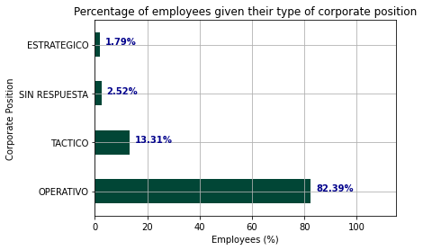

```python
z='CARGO_CORPORATIVO'

y=list(data[z].value_counts().index)
x=list(data[z].value_counts().values)
x_p=list(np.round(data[z].value_counts().values/sum(data[z].value_counts().values),4)*100)

d=pd.DataFrame({'Corporate Position':y, 'Employees':x, '%':x_p})

d.plot(x='Corporate Position',y='%', kind='barh', colormap='PuBuGn_r', grid=True, legend=False)

for i in range(d.shape[0]):
    plt.text(d['%'][i]+2,i,str(round(d['%'][i],2))+'%',color='darkblue',size='medium',weight=1000)
plt.ylabel('Corporate Position')
plt.xlabel('Employees (%)')
plt.title('Percentage of employees given their type of corporate position')
plt.xlim(0,115)

plt.show()
```

## CAUSAL_FIN_CONTRATO

There are 29 different causes to end the contract within this database. The most common cause is "04-FIN DE OBRA O LABOR" with 33.8\% attendance.

```python
z='CAUSAL_FIN_CONTRATO'

y=list(data[z].value_counts().index)
x=list(data[z].value_counts().values)
x_p=list(np.round(data[z].value_counts().values/sum(data[z].value_counts().values),4)*100)

d=pd.DataFrame({'Reason':y, 'Employees':x, '%':x_p})

d.head(10)
```

|  | Reason | Employees | % |
| --- | --- | --- | --- |
| 0 | 04-FIN DE OBRA O LABOR | 41416 | 33.80 |
| 1 | 41-RENUNCIA VOLUNTARIA | 39148 | 31.95 |
| 2 | NONE | 26411 | 21.56 |
| 3 | 57-DESPIDO CON JUSTA CAUSA | 4918 | 4.01 |
| 4 | 05-PERIODO DE PRUEBA | 3847 | 3.14 |
| 5 | 46-VINCULACION DIRECTA CON LA EMPRESA | 3272 | 2.67 |
| 6 | 08-CUMPLIMIENTO DEL TERMINO FIJO | 1269 | 1.04 |
| 7 | 01-DESPIDO SIN JUSTA CAUSA | 546 | 0.45 |
| 8 | 21-FINALIZACION DE CONTRATOS | 439 | 0.36 |
| 9 | 13-ABANDONO DE CARGO | 356 | 0.29 |

Given the existence of categories with low presence, we proceed to group them together, which represent approximately 5\% as shown below:

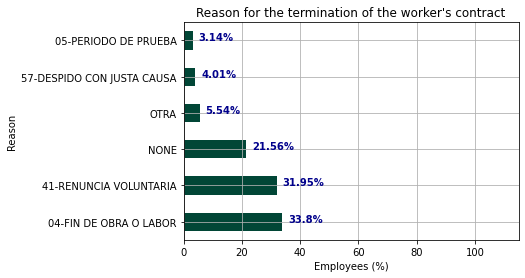

```python
razon=['04-FIN DE OBRA O LABOR','41-RENUNCIA VOLUNTARIA','NONE','57-DESPIDO CON JUSTA CAUSA','05-PERIODO DE PRUEBA']
data['CAUSAL_FIN_CONTRATO_2']=np.nan

for i in range(data.shape[0]):
    if data['CAUSAL_FIN_CONTRATO'][i] in razon:
        data['CAUSAL_FIN_CONTRATO_2'][i] = data['CAUSAL_FIN_CONTRATO'][i]
    else:
        data['CAUSAL_FIN_CONTRATO_2'][i] = 'OTRA'

z='CAUSAL_FIN_CONTRATO_2'

y=list(data[z].value_counts().index)
x=list(data[z].value_counts().values)
x_p=list(np.round(data[z].value_counts().values/sum(data[z].value_counts().values),4)*100)

d=pd.DataFrame({'Reason':y, 'Employees':x, '%':x_p})

d.plot(x='Reason',y='%', kind='barh', colormap='PuBuGn_r', grid=True, legend=False)

for i in range(d.shape[0]):
    plt.text(d['%'][i]+2,i,str(round(d['%'][i],2))+'%',color='darkblue',size='medium',weight=1000)
plt.ylabel('Reason')
plt.xlabel('Employees (%)')
plt.title("Reason for the termination of the worker's contract")
plt.xlim(0,115)

plt.show()
```

## ESTRATO

The employees are distributed in three strata, LOW, MEDIUM AND HIGH. Employees who do not have registration are assigned "NO REGISTRA". The presence of category within the variable is shown below:

```python
z='ESTRATO'

y=list(data[z].value_counts().index)
x=list(data[z].value_counts().values)
x_p=list(np.round(data[z].value_counts().values/sum(data[z].value_counts().values),4)*100)

d=pd.DataFrame({'Corporate Position':y, 'Employees':x, '%':x_p});d
```

|  | Corporate Position | Employees | % |
| --- | --- | --- | --- |
| 0 | BAJO | 94570 | 77.18 |
| 1 | MEDIO | 26746 | 21.83 |
| 2 | ALTO | 878 | 0.72 |
| 3 | NONE | 330 | 0.27 |

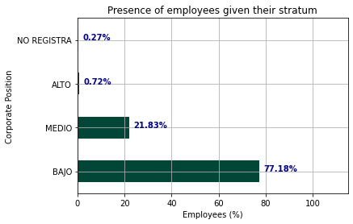

```python
data['ESTRATO_2']=np.nan

for i in range(data.shape[0]):
    if data['ESTRATO'][i] == 'NONE':
        data['ESTRATO_2'][i] = 'NO REGISTRA'
    else:
        data['ESTRATO_2'][i] = data['ESTRATO'][i]

z='ESTRATO_2'

y=list(data[z].value_counts().index)
x=list(data[z].value_counts().values)
x_p=list(np.round(data[z].value_counts().values/sum(data[z].value_counts().values),4)*100)

d=pd.DataFrame({'Corporate Position':y, 'Employees':x, '%':x_p})

d.plot(x='Corporate Position',y='%', kind='barh', colormap='PuBuGn_r', grid=True, legend=False)

for i in range(d.shape[0]):
    plt.text(d['%'][i]+2,i,str(round(d['%'][i],2))+'%',color='darkblue',size='medium',weight=1000)
plt.ylabel('Corporate Position')
plt.xlabel('Employees (%)')
plt.title('Presence of employees given their stratum')
plt.xlim(0,115)

plt.show()
```

## NIVEL_ESTUDIO

To observe the distribution of employees with respect to their level of education, the frequency of each category is presented:

```python
z='NIVEL_ESTUDIO'

y=list(data[z].value_counts().index)
x=list(data[z].value_counts().values)
x_p=list(np.round(data[z].value_counts().values/sum(data[z].value_counts().values),4)*100)

d=pd.DataFrame({'Level':y, 'Employees':x, '%':x_p})

d
```

|  | Level | Employees | % |
| --- | --- | --- | --- |
| 0 | BACHILLERATO | 65320 | 53.31 |
| 1 | CARRERA TECNICA | 22375 | 18.26 |
| 2 | CARRERA TECNOLOGICA | 11670 | 9.52 |
| 3 | PROFESIONAL (PREGRADO) | 9283 | 7.58 |
| 4 | SIN DEFINIR | 9197 | 7.51 |
| 5 | NONE | 2382 | 1.94 |
| 6 | DIPLOMADO/SEMINARIO/CURSO/TALLER | 1130 | 0.92 |
| 7 | ESPECIALISTA | 934 | 0.76 |
| 8 | PROFESIONAL CON MAESTRIA | 131 | 0.11 |
| 9 | SIN ESTUDIOS FORMALES | 90 | 0.07 |
| 10 | DOCTORADO | 8 | 0.01 |
| 11 | ESTUDIANTE EDUCACION CONTINUA | 3 | 0.00 |
| 12 | ESTUDIANTE DOCTORADO | 1 | 0.00 |

Given the low presence of some categories, we proceed to group them into one so that they add up to 3.8\% of the total number of records, finally having six categories as shown below:

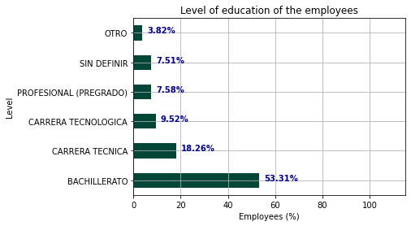

```python
nivel=['BACHILLERATO','CARRERA TECNICA','CARRERA TECNOLOGICA','PROFESIONAL (PREGRADO)','SIN DEFINIR']
data['NIVEL_ESTUDIO_2']=np.nan

for i in range(data.shape[0]):
    if data['NIVEL_ESTUDIO'][i] in nivel:
        data['NIVEL_ESTUDIO_2'][i]=data['NIVEL_ESTUDIO'][i]
    else:
        data['NIVEL_ESTUDIO_2'][i]='OTRO'

z='NIVEL_ESTUDIO_2'

y=list(data[z].value_counts().index)
x=list(data[z].value_counts().values)
x_p=list(np.round(data[z].value_counts().values/sum(data[z].value_counts().values),4)*100)

d=pd.DataFrame({'Level':y, 'Employees':x, '%':x_p})

d.plot(x='Level',y='%', kind='barh', colormap='PuBuGn_r', grid=True, legend=False)

for i in range(d.shape[0]):
    plt.text(d['%'][i]+2,i,str(round(d['%'][i],2))+'%',color='darkblue',size='medium',weight=1000)
plt.ylabel('Level')
plt.xlabel('Employees (%)')
plt.title('Level of education of the employees')
plt.xlim(0,115)

plt.show()
```

## ESTADO_CIVIL

There are nine different marital statuses for the group of employees, of these, three states accumulate 93.25\% presence in the variable as shown below:

```python
z='ESTADO_CIVIL'

y=list(data[z].value_counts().index)
x=list(data[z].value_counts().values)
x_p=list(np.round(data[z].value_counts().values/sum(data[z].value_counts().values),4)*100)

d=pd.DataFrame({'Marital status':y, 'Employees':x, '%':x_p})

d.head(10)
```

|  | Marital status | Employees | % |
| --- | --- | --- | --- |
| 0 | SOLTERO/A | 71643 | 58.47 |
| 1 | UNION LIBRE | 32467 | 26.50 |
| 2 | CASADO | 10144 | 8.28 |
| 3 | SIN_DEFINIR | 4579 | 3.74 |
| 4 | SEPARADO/A | 2106 | 1.72 |
| 5 | COHABITANTE | 840 | 0.69 |
| 6 | CASADO/A | 477 | 0.39 |
| 7 | VIUDO/A | 158 | 0.13 |
| 8 | NINGUNO | 110 | 0.09 |

Given the low presence of some categories, we proceed to group them in such a way that they represent 6.75\% of the records. Finally the variable ends up with four categories as shown below:

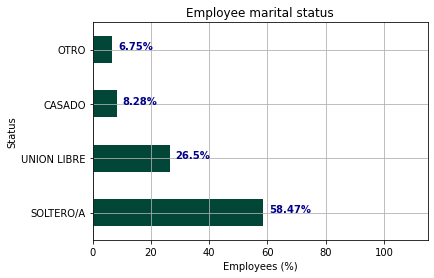

```python
data['ESTADO_CIVIL_2']=np.nan
estado=['SOLTERO/A','UNION LIBRE','CASADO']

for i in range(data.shape[0]):
    if data['ESTADO_CIVIL'][i] in estado:
        data['ESTADO_CIVIL_2'][i] = data['ESTADO_CIVIL'][i]
    else:
        data['ESTADO_CIVIL_2'][i] = 'OTRO'

z='ESTADO_CIVIL_2'

y=list(data[z].value_counts().index)
x=list(data[z].value_counts().values)
x_p=list(np.round(data[z].value_counts().values/sum(data[z].value_counts().values),4)*100)

d=pd.DataFrame({'Status':y, 'Employees':x, '%':x_p})

d.plot(x='Status',y='%', kind='barh', colormap='PuBuGn_r', grid=True, legend=False)

for i in range(d.shape[0]):
    plt.text(d['%'][i]+2,i,str(round(d['%'][i],2))+'%',color='darkblue',size='medium',weight=1000)
plt.ylabel('Status')
plt.xlabel('Employees (%)')
plt.title('Employee marital status')
plt.xlim(0,115)

plt.show()
```

## SECTOR

There are thirteen economic sectors where employees work, five of these accumulate 96.3\% of the records as shown below:

```python
z='SECTOR'

y=list(data[z].value_counts().index)
x=list(data[z].value_counts().values)
x_p=list(np.round(data[z].value_counts().values/sum(data[z].value_counts().values),4)*100)

d=pd.DataFrame({'Sector':y, 'Employees':x, '%':x_p})

d.head(10)
```

|  | Sector | Employees | % |
| --- | --- | --- | --- |
| 0 | SECTOR | 39325 | 32.10 |
| 1 | INDUSTRIAS MANUFACTURERAS | 36151 | 29.51 |
| 2 | COMERCIO AL POR MAYOR Y AL POR MENOR; REPARACI... | 24455 | 19.96 |
| 3 | INFORMACION Y COMUNICACIONES | 10532 | 8.60 |
| 4 | ACTIVIDADES DE SERVICIOS ADMINISTRATIVOS Y DE ... | 7536 | 6.15 |
| 5 | AGRICULTURA, GANADERIA, CAZA, SILVICULTURA Y P... | 2121 | 1.73 |
| 6 | ALOJAMIENTO Y SERVICIOS DE COMIDA | 1576 | 1.29 |
| 7 | EXPLOTACION DE MINAS Y CANTERAS | 599 | 0.49 |
| 8 | OTRAS ACTIVIDADES DE SERVICIOS | 184 | 0.15 |
| 9 | SUMINISTRO DE ELECTRICIDAD, GAS, VAPOR Y AIRE ... | 32 | 0.03 |

Given the low presence of some categories, we proceed to group them in such a way that they represent 3.69\% of presence within the variable. Finally, six categories are registered as shown below:

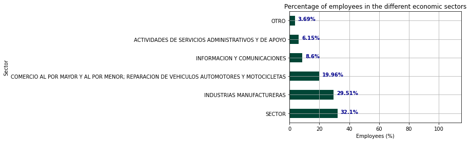

```python
sector=d['Sector'].head(5).to_list()
data['SECTOR_2']=np.nan

for i in range(data.shape[0]):
    if data['SECTOR'][i] in sector:
        data['SECTOR_2'][i] = data['SECTOR'][i]
    else:
        data['SECTOR_2'][i] = 'OTRO'

z='SECTOR_2'

y=list(data[z].value_counts().index)
x=list(data[z].value_counts().values)
x_p=list(np.round(data[z].value_counts().values/sum(data[z].value_counts().values),4)*100)

d=pd.DataFrame({'Sector':y, 'Employees':x, '%':x_p})

d.plot(x='Sector',y='%', kind='barh', colormap='PuBuGn_r', grid=True, legend=False)

for i in range(d.shape[0]):
    plt.text(d['%'][i]+2,i,str(round(d['%'][i],2))+'%',color='darkblue',size='medium',weight=1000)
plt.ylabel('Sector')
plt.xlabel('Employees (%)')
plt.title('Percentage of employees in the different economic sectors')
plt.xlim(0,115)

plt.show()
```

```python
data_2=data[['IDENTIFICADOR','COD_CIUDAD_LABOR','CIUDAD_RESIDENCIA','NRO_HIJOS','CIUDAD_LABOR','JORNADA_LABORAL_MES','FECHA_NACIMIENTO','EDAD_2','GENERACION','GENERO','COD_CLIENTE','CODIGO_LINEA','REGIONAL','TIPO_CONTRATO_2','OT','FONDEX_2','NEGOCIO','FECHA_INGRESO','FECHA_INGRESO_2','FECHA_RETIRO','FECHA_RETIRO_2','NIVEL_RIESGO','LINEA_SERVICIO_2','EPS_COD','EPS_2','COD_CARGO','CARGO','CARGO_CORPORATIVO','CAUSAL_FIN_CONTRATO_2','ESTRATO_2','NIVEL_ESTUDIO_2','ESTADO_CIVIL_2','FECHA_ACT','INACTIVO','ACTIVO','ALTA','SECTOR_2']]
```

```python
data_2.info()
```

```
<class 'pandas.core.frame.DataFrame'>
RangeIndex: 122524 entries, 0 to 122523
Data columns (total 37 columns):
 #   Column                 Non-Null Count   Dtype
---  ------                 --------------   -----
 0   IDENTIFICADOR          122524 non-null  object
 1   COD_CIUDAD_LABOR       122524 non-null  int64
 2   CIUDAD_RESIDENCIA      122524 non-null  object
 3   NRO_HIJOS              122524 non-null  int64
 4   CIUDAD_LABOR           122524 non-null  object
 5   JORNADA_LABORAL_MES    122524 non-null  int64
 6   FECHA_NACIMIENTO       122524 non-null  datetime64[ns]
 7   EDAD_2                 122524 non-null  object
 8   GENERACION             122524 non-null  object
 9   GENERO                 122524 non-null  object
```

[output cut: 29 more lines]

```python
data_2.to_csv('data_2.csv',sep=';')
```